# The Player Problem - The share of space portioned to different audio playback devices in Audio Magazine between 1973-1999

Marcus Fryd

2026-05-26

### Packages used:

```r
knitr::opts_chunk$set(echo = TRUE,
                      warning = FALSE,
                      message = FALSE)


library(tidyverse)
library(here)
```

```r
# For text mining and plotting:

library(pdftools)
library(tidytext)
library(textdata)
library(ggwordcloud)
```

### Getting the Audio magazines and placing them in a tibble:

In the following, we will be loading the Audio magazines into R. The first step towards plotting them by year is combining all issues released in a given year into one PDF. To do this, we will be using ‘pdf_combine()’ from the pdftools package. After combining the PDFs, we need to load them into a tibble with their entire text. This is possible thanks to the ‘pdf_text()’ function from idem package.

```r
# In the following, we will load the full text of the Audio Magazines.

audio_files <- here("data/audio_1947_2000/used_issues") %>% # <- 'here()' defines the path
  list.files(pattern="pdf$",full.names=T)  # <- 'list.files()' in this case lists all files with 'pdf' in the end (meaning all .pdf files) and their full name, meaning the entire path


# Now we will combine the PDFs by their year (lines 49-53 were partly generated by ChatGPT-5.5)

audio_year <- str_extract(basename(audio_files),"\\d{4}")
audio_files_by_year <- split(audio_files,audio_year)

lapply(names(audio_files_by_year), function(year) {
  pdf_combine(input = audio_files_by_year[[year]],
    output = paste0("/Users/fryga/Documents/rstudio projects/DAM_final_project/data/audio_by_year_1973_1999/", year,".pdf")
  )
})
```

```
## [[1]]
## [1] "C:\\Users\\fryga\\Documents\\rstudio projects\\DAM_final_project\\data\\audio_by_year_1973_1999\\1973.pdf"
##
## [[2]]
## [1] "C:\\Users\\fryga\\Documents\\rstudio projects\\DAM_final_project\\data\\audio_by_year_1973_1999\\1974.pdf"
##
## [[3]]
## [1] "C:\\Users\\fryga\\Documents\\rstudio projects\\DAM_final_project\\data\\audio_by_year_1973_1999\\1975.pdf"
##
## [[4]]
## [1] "C:\\Users\\fryga\\Documents\\rstudio projects\\DAM_final_project\\data\\audio_by_year_1973_1999\\1976.pdf"
##
## [[5]]
## [1] "C:\\Users\\fryga\\Documents\\rstudio projects\\DAM_final_project\\data\\audio_by_year_1973_1999\\1977.pdf"
##
## [[6]]
## [1] "C:\\Users\\fryga\\Documents\\rstudio projects\\DAM_final_project\\data\\audio_by_year_1973_1999\\1978.pdf"
##
## [[7]]
## [1] "C:\\Users\\fryga\\Documents\\rstudio projects\\DAM_final_project\\data\\audio_by_year_1973_1999\\1979.pdf"
##
## [[8]]
## [1] "C:\\Users\\fryga\\Documents\\rstudio projects\\DAM_final_project\\data\\audio_by_year_1973_1999\\1980.pdf"
##
## [[9]]
## [1] "C:\\Users\\fryga\\Documents\\rstudio projects\\DAM_final_project\\data\\audio_by_year_1973_1999\\1981.pdf"
##
## [[10]]
## [1] "C:\\Users\\fryga\\Documents\\rstudio projects\\DAM_final_project\\data\\audio_by_year_1973_1999\\1982.pdf"
##
## [[11]]
## [1] "C:\\Users\\fryga\\Documents\\rstudio projects\\DAM_final_project\\data\\audio_by_year_1973_1999\\1983.pdf"
##
## [[12]]
## [1] "C:\\Users\\fryga\\Documents\\rstudio projects\\DAM_final_project\\data\\audio_by_year_1973_1999\\1984.pdf"
##
## [[13]]
## [1] "C:\\Users\\fryga\\Documents\\rstudio projects\\DAM_final_project\\data\\audio_by_year_1973_1999\\1985.pdf"
##
## [[14]]
```

[output cut: 25 more lines]

```
##
## [[23]]
## [1] "C:\\Users\\fryga\\Documents\\rstudio projects\\DAM_final_project\\data\\audio_by_year_1973_1999\\1995.pdf"
##
## [[24]]
## [1] "C:\\Users\\fryga\\Documents\\rstudio projects\\DAM_final_project\\data\\audio_by_year_1973_1999\\1996.pdf"
##
## [[25]]
## [1] "C:\\Users\\fryga\\Documents\\rstudio projects\\DAM_final_project\\data\\audio_by_year_1973_1999\\1997.pdf"
##
## [[26]]
## [1] "C:\\Users\\fryga\\Documents\\rstudio projects\\DAM_final_project\\data\\audio_by_year_1973_1999\\1998.pdf"
##
## [[27]]
## [1] "C:\\Users\\fryga\\Documents\\rstudio projects\\DAM_final_project\\data\\audio_by_year_1973_1999\\1999.pdf"
```

```r
# We have moved the output PDFs into a new folder under "/data". Below we will load in the full text of these new PDFs as a tibble (lines 58-61 were partly generated by ChatGPT-5.5)

audio_dir <- "data/audio_by_year_1973_1999"
audio_tbl <- tibble(
  file=list.files(audio_dir,pattern=".pdf$",full.names = TRUE)) %>%
  mutate(year=tools::file_path_sans_ext(basename(file)),
    text_clean=map(file,~paste(pdf_text(.x),collapse="\n"))) %>%
  mutate(text_clean=str_split(text_clean, pattern = '\n')) %>%
  unnest(text_clean) %>%
  mutate(text_clean=str_trim(text_clean))
head(audio_tbl)
```

```
## # A tibble: 6 × 3
##   file                                  year  text_clean
##   <chr>                                 <chr> <chr>
## 1 data/audio_by_year_1973_1999/1973.pdf 1973  "23602"
## 2 data/audio_by_year_1973_1999/1973.pdf 1973  ""
## 3 data/audio_by_year_1973_1999/1973.pdf 1973  ""
## 4 data/audio_by_year_1973_1999/1973.pdf 1973  "Canby"
## 5 data/audio_by_year_1973_1999/1973.pdf 1973  "Looks at Flat Speakers"
## 6 data/audio_by_year_1973_1999/1973.pdf 1973  "New Tuner Specs for 73"
```

### Defining audio equipment, textmining, and plotting the findings:

Now that we have the full text in a tibble, we can start actually textmining. For our purpose, we will be using four “term groups”, that is vectors containing (shortened) words for different audio playback devices. We will be looking for players for these four formats: Cassettes, CDs, records, and 8-tracks.

```r
# We will start by defining the term groups, after which we will plot the findings (lines 86-106 were partly generated by ChatGPT-5.5):

term_groups <- list(Turntable=c("turntable", "record pl", "turntables"),
  Cassette=c("cassette pl", "tapedeck", "cassette de","tapedecks", "cassette decks","compact cassette de","compact cassette pl","walkman","portable casset"),
  CD=c("cdpl", "cd pl", "compact disc pl","cd-pl", "compact disk pl", "disc pl","cd-r pl","cd-rom pl", "cd-rw pl","cdchang","cd chang","compact disc chang","compact disk chang","cd-chang","discman","portable cd"),
  "8-track"=c("8-track pl","8-track d", "8 track pl","8-track tape pl","8 track d", "8 track tape pl","4-channel tape d","4 channel tape d","4-channel cartridge d","4 channel cartridge d","4-channel cartridge tape d","4 channel cartridge tape d")
)


audio_counts <- audio_tbl %>%
  bind_cols(
    map_dfc(term_groups, function(synonyms) {
      rowSums(
        sapply(synonyms, function(term) {
          str_count(audio_tbl$text_clean, regex(term, ignore_case = TRUE))
        }),
        na.rm = TRUE
      )
    }) %>%
      set_names(names(term_groups))
  )
audio_counts
```

```
## # A tibble: 3,677,605 × 7
##    file                      year  text_clean Turntable Cassette    CD `8-track`
##    <chr>                     <chr> <chr>          <dbl>    <dbl> <dbl>     <dbl>
##  1 data/audio_by_year_1973_… 1973  "23602"            0        0     0         0
##  2 data/audio_by_year_1973_… 1973  ""                 0        0     0         0
##  3 data/audio_by_year_1973_… 1973  ""                 0        0     0         0
##  4 data/audio_by_year_1973_… 1973  "Canby"            0        0     0         0
##  5 data/audio_by_year_1973_… 1973  "Looks at…         0        0     0         0
##  6 data/audio_by_year_1973_… 1973  "New Tune…         0        0     0         0
##  7 data/audio_by_year_1973_… 1973  "Audio lo…         0        0     0         0
##  8 data/audio_by_year_1973_… 1973  "\"UNPIN …         0        0     0         0
##  9 data/audio_by_year_1973_… 1973  ""                 0        0     0         0
## 10 data/audio_by_year_1973_… 1973  "-       …         0        0     0         0
## # ℹ 3,677,595 more rows
```

```r
yearly_counts <- audio_counts %>%
  group_by(year) %>%
  summarise(
  across(all_of(names(term_groups)), \(x) sum(x, na.rm = TRUE))
) %>%
  pivot_longer(-year, names_to = "Format", values_to = "Count")

yearly_counts$year <- as.numeric(yearly_counts$year)
yearly_counts
```

```
## # A tibble: 108 × 3
##     year Format    Count
##    <dbl> <chr>     <dbl>
##  1  1973 Turntable   686
##  2  1973 Cassette    102
##  3  1973 CD            8
##  4  1973 8-track       3
##  5  1974 Turntable   785
##  6  1974 Cassette     83
##  7  1974 CD            2
##  8  1974 8-track       0
##  9  1975 Turntable   904
## 10  1975 Cassette    131
## # ℹ 98 more rows
```

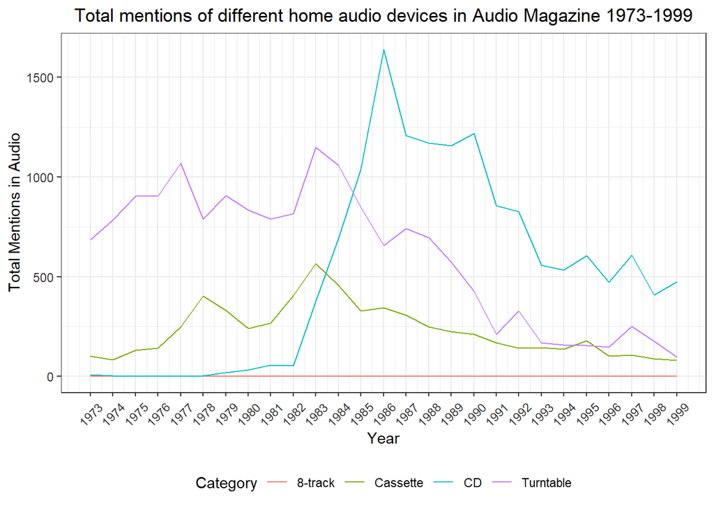

```r
audio_graph <- yearly_counts %>%
  group_by(Format) %>%
  ggplot() +
  geom_line(aes(x=year,y=Count,color=Format,group=Format)) +
  scale_x_continuous(breaks=seq(1973,1999,by=1))+
  labs(title = "Total mentions of different home audio devices in Audio Magazine 1973-1999",
       x = "Year",
       y = "Total Mentions in Audio",
       color = "Category")+
  theme_bw()+
  theme(legend.position = "bottom",
        axis.text.x = element_text(color = "grey20", angle = 45,
                                     hjust = 0.5, vjust = 0.5),
          axis.text.y = element_text(color = "grey20"),
          text = element_text(size = 11),
          plot.title = element_text(hjust = 0.5),
        plot.subtitle = element_text(hjust = 0.5))
audio_graph
```

```r
ggsave("figures\\audio_mentions_graph.png", plot = audio_graph, width = 10, height = 5, bg = "white")
```

### Getting and plotting Recording Industry Association of America data:

We can now load in the data from our “format_revenue” table with the ‘read_csv2’ function from the tidyverse package. This can then easily be plotted in a similar fashion to how we plotted the data from our textmining above:

```r
# We start by loading in the tidied up dataset as a tibble:

format_revenue <- read_csv2("data/format_revenue.csv")
head(format_revenue)
```

```
## # A tibble: 6 × 6
##   index Format     Year      Units   Revenue `Revenue (Inflation Adjusted)`
##   <dbl> <chr>     <dbl>      <dbl>     <dbl>                          <dbl>
## 1     0 8 - Track  1973  910000000 489000000                     2699600000
## 2     1 8 - Track  1974  967000000 549200000                     2730600000
## 3     2 8 - Track  1975  946000000 583000000                     2656200000
## 4     3 8 - Track  1976 1061000000 678200000                     2921600000
## 5     4 8 - Track  1977 1273000000 811000000                     3280400000
## 6     5 8 - Track  1978 1336000000 948000000                     3564000000
```

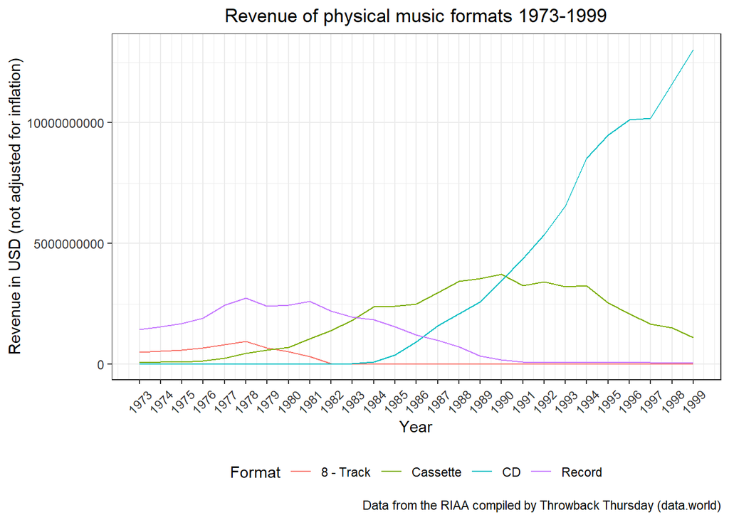

```r
# Before continuing with plotting the data, we have to ensure the graph shows us standard form of number and not the scientific notation, which becomes the default when dealing with larger number. To ensure this, we execute the following line (credits to Sacha Epskamp on Stack Overflow)

options(scipen = 999)

# We can now plot our data with the 'geom_line' function of ggplot2.

format_revenue_plot<- format_revenue %>%
  filter(Year<"2000") %>%
  ggplot()+
  geom_line(mapping=aes(x=Year, y=Revenue,
                        color=Format,))+
  scale_x_continuous(breaks=seq(1973,1999,by=1))+
  labs(title="Revenue of physical music formats 1973-1999",
       caption = "Data from the RIAA compiled by Throwback Thursday (data.world)",
    x="Year",
    y="Revenue in USD (not adjusted for inflation)",
    color="Format")+
  theme_bw()+
  theme(legend.position = "bottom",
        axis.text.x = element_text(color = "grey20", angle = 45,
                                     hjust = 0.5, vjust = 0.5),
          axis.text.y = element_text(color = "grey20"),
          text = element_text(size = 11),
          plot.title = element_text(hjust = 0.5))
format_revenue_plot
```

```r
ggsave("figures\\formats_revenue_graph.png", plot = format_revenue_plot, width = 10, height = 5, bg = "white")
```

### Investigating most common words in Audio Magazine before and after 1987

In the following chunk, we will being investigating what the most common words were in Audio Magazine after and including 1987, since we saw a dip in the mentions of CD players. We will similarly be investigating what the most common words were before 1987 afterwards

```r
# We will start by tokenizing our audio_tbl filtered to only contain the years 1987 to 1999:

audio_tokenize_87 <- audio_tbl %>%
  filter(year>=1987) %>%
  unnest_tokens(word, text_clean)
audio_tokenize_87
```

```
## # A tibble: 14,041,503 × 3
##    file                                  year  word
##    <chr>                                 <chr> <chr>
##  1 data/audio_by_year_1973_1999/1987.pdf 1987  a
##  2 data/audio_by_year_1973_1999/1987.pdf 1987  i
##  3 data/audio_by_year_1973_1999/1987.pdf 1987  january
##  4 data/audio_by_year_1973_1999/1987.pdf 1987  1987
##  5 data/audio_by_year_1973_1999/1987.pdf 1987  2.25
##  6 data/audio_by_year_1973_1999/1987.pdf 1987  threshold
##  7 data/audio_by_year_1973_1999/1987.pdf 1987  1
##  8 data/audio_by_year_1973_1999/1987.pdf 1987  sa
##  9 data/audio_by_year_1973_1999/1987.pdf 1987  1
## 10 data/audio_by_year_1973_1999/1987.pdf 1987  amplifier
## # ℹ 14,041,493 more rows
```

```r
# In the following, we will load in an English stopword list.
## Afterwards, we will use the 'anti_join()' function to remove the stopwords from the tokenized tibble:

stop_words_eng <- read_csv("data/english_stopwords.txt")

audio_stop_87 <- audio_tokenize_87 %>%
  anti_join(stop_words_eng)


# Below, we will filter all numbers, since those are not particularly interesting:

audio_no_numeric_87 <- audio_stop_87 %>%
  filter(is.na(as.numeric(word)))


# We will now count all words and sort them from most to fewest mentions:

audio_word_count_87 <- audio_no_numeric_87 %>%
  count(word) %>%
  group_by(word) %>%
  summarise(n = sum(as.numeric(n)), .groups = "drop") %>%
  arrange(-n)
audio_word_count_87
```

```
## # A tibble: 293,281 × 2
##    word       n
##    <chr>  <dbl>
##  1 audio  81516
##  2 sound  50033
##  3 cd     26628
##  4 power  26444
##  5 high   26434
##  6 music  25711
##  7 stereo 25072
##  8 db     23190
##  9 system 23075
## 10 dome   21500
## # ℹ 293,271 more rows
```

Since the process is the same as above, there are no explanations as to what is being done.

```r
audio_tokenize_73 <- audio_tbl %>%
  filter(year<1987) %>%
  unnest_tokens(word, text_clean)
audio_tokenize_73
```

```
## # A tibble: 13,239,852 × 3
##    file                                  year  word
##    <chr>                                 <chr> <chr>
##  1 data/audio_by_year_1973_1999/1973.pdf 1973  23602
##  2 data/audio_by_year_1973_1999/1973.pdf 1973  canby
##  3 data/audio_by_year_1973_1999/1973.pdf 1973  looks
##  4 data/audio_by_year_1973_1999/1973.pdf 1973  at
##  5 data/audio_by_year_1973_1999/1973.pdf 1973  flat
##  6 data/audio_by_year_1973_1999/1973.pdf 1973  speakers
##  7 data/audio_by_year_1973_1999/1973.pdf 1973  new
##  8 data/audio_by_year_1973_1999/1973.pdf 1973  tuner
##  9 data/audio_by_year_1973_1999/1973.pdf 1973  specs
## 10 data/audio_by_year_1973_1999/1973.pdf 1973  for
## # ℹ 13,239,842 more rows
```

```r
audio_stop_73 <- audio_tokenize_73 %>%
  anti_join(stop_words_eng)


audio_no_numeric_73 <- audio_stop_73 %>%
  filter(is.na(as.numeric(word)))


audio_word_count_73 <- audio_no_numeric_73 %>%
  count(word) %>%
  group_by(word) %>%
  summarise(n = sum(as.numeric(n)), .groups = "drop") %>%
  arrange(-n)
audio_word_count_73
```

```
## # A tibble: 244,574 × 2
##    word          n
##    <chr>     <dbl>
##  1 audio     68008
##  2 sound     46116
##  3 stereo    31184
##  4 high      29758
##  5 tape      29515
##  6 db        27188
##  7 system    24263
##  8 power     23606
##  9 music     21796
## 10 frequency 21471
## # ℹ 244,564 more rows
```

### Wordclouds of the top 100 most common words in Audio Magazine before and after 1987

We will now make two wordclouds over the top 100 most words in Audio Magazine before and after 1987. We will not do a wordcloud over all the words, since that would be far too large to analyze anything interesting. To do this, we will have to firstly make a top 100 tibble, which is easily done with the ‘head()’ function. We will start with after 1987:

```r
# By writing 100 in the 'head()' function, we can view only the top 100, so it is only a matter of assigning the function a new name:

audio_top100_87 <- audio_word_count_87 %>%
  head(100)
audio_top100_87
```

```
## # A tibble: 100 × 2
##    word       n
##    <chr>  <dbl>
##  1 audio  81516
##  2 sound  50033
##  3 cd     26628
##  4 power  26444
##  5 high   26434
##  6 music  25711
##  7 stereo 25072
##  8 db     23190
##  9 system 23075
## 10 dome   21500
## # ℹ 90 more rows
```

Now, onto before 1987:

```r
audio_top100_73 <- audio_word_count_73 %>%
  head(100)
audio_top100_73
```

```
## # A tibble: 100 × 2
##    word          n
##    <chr>     <dbl>
##  1 audio     68008
##  2 sound     46116
##  3 stereo    31184
##  4 high      29758
##  5 tape      29515
##  6 db        27188
##  7 system    24263
##  8 power     23606
##  9 music     21796
## 10 frequency 21471
## # ℹ 90 more rows
```

We are now able to make wordclouds using the ‘geom_text_wordcloud_area’ function under a ggplot pipeline. Let us begin with 1987-1999:

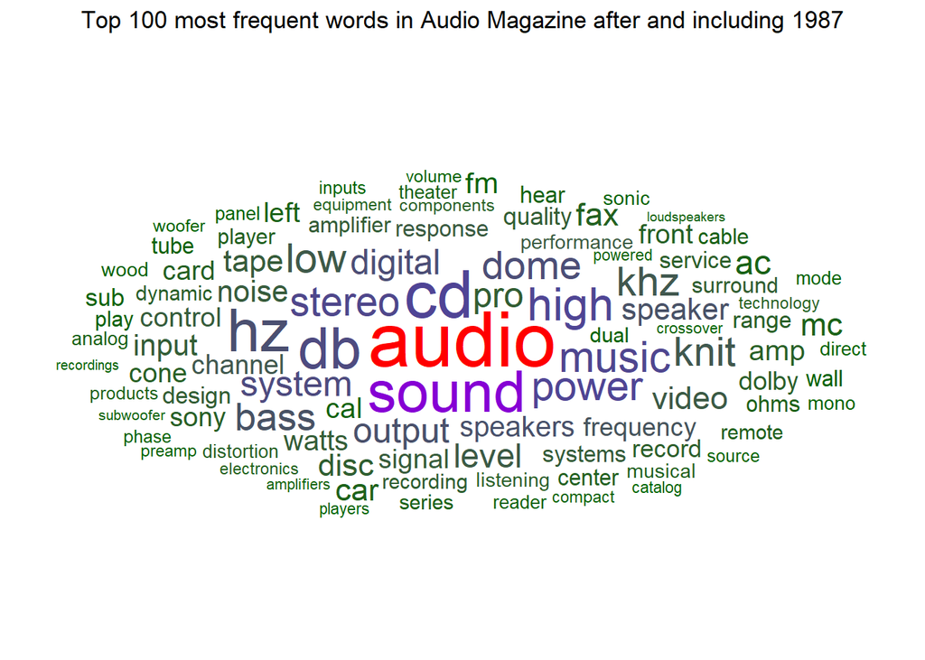

```r
# We will determine frequency by color: The more frequently a word appeares (i.e., the higher an "n" value), the redder. Afterwards, less frequent words (a lower "n" value) turn purple, then blue. The least frequent of the top 100 most frequent words will be green.

audio_t100_word_cloud_87 <- ggplot(data = audio_top100_87, aes(label = word, size = n)) +
  geom_text_wordcloud_area(aes(color = n)) +
  scale_size_area(max_size = 30) +
  scale_color_gradientn(colors = c("darkgreen","blue","red")) +
  labs(title="Top 100 most frequent words in Audio Magazine after and including 1987")+
  theme_minimal()+
  theme(text = element_text(size = 11),
        plot.title = element_text(hjust = 0.5))
audio_t100_word_cloud_87
```

```r
ggsave("figures\\audio_t100_word_cloud_87.png", plot = audio_t100_word_cloud_87, bg = "white")
```

And now before 1987 (same as above):

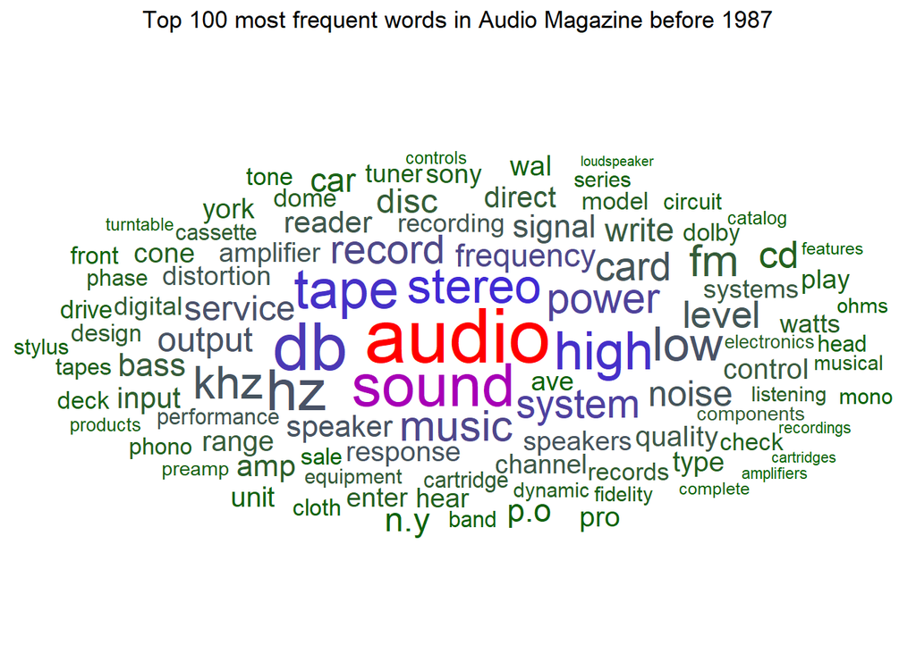

```r
audio_t100_word_cloud_73 <- ggplot(data = audio_top100_73, aes(label = word, size = n)) +
  geom_text_wordcloud_area(aes(color = n)) +
  scale_size_area(max_size = 30) +
  scale_color_gradientn(colors = c("darkgreen","blue","red")) +
  labs(title="Top 100 most frequent words in Audio Magazine before 1987")+
  theme_minimal()+
  theme(text = element_text(size = 11),
        plot.title = element_text(hjust = 0.5))
audio_t100_word_cloud_73
```

```r
ggsave("figures\\audio_t100_word_cloud_73.png", plot = audio_t100_word_cloud_73, bg = "white")
```

It is very quite difficult to see which words are unique to the period 1987-1999. We can use the ‘anti_join’ function on our top 100 objects to remove the words not unique to the period after 1987 and plot that as a wordcloud:

```r
# We start by anti-joining the two top 100 objects from above

audio_73_87_anti <- audio_top100_87 %>%
  anti_join(audio_top100_73,
            by = "word")
audio_73_87_anti
```

```
## # A tibble: 33 × 2
##    word           n
##    <chr>      <dbl>
##  1 knit       14975
##  2 video      13418
##  3 surround   10240
##  4 center      8004
##  5 technology  7969
##  6 player      7922
##  7 fax         7907
##  8 remote      7438
##  9 mc          6842
## 10 cable       6735
## # ℹ 23 more rows
```

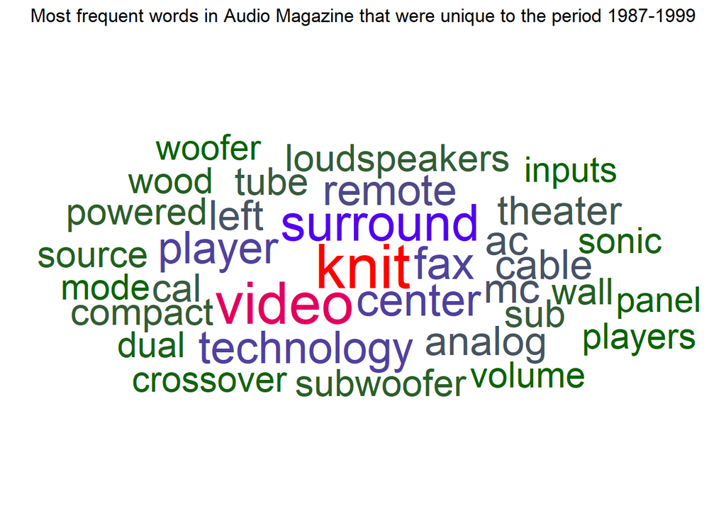

```r
# We can now use the same wordcloud code from before to plot this:

audio_t100_word_cloud_anti <- ggplot(data = audio_73_87_anti, aes(label = word, size = n)) +
  geom_text_wordcloud(aes(color = n)) +
  scale_size_area(max_size = 15) +
  scale_color_gradientn(colors = c("darkgreen","blue","red")) +
  labs(title="Most frequent words in Audio Magazine that were unique to the period 1987-1999")+
  theme_minimal()+
  theme(text = element_text(size = 11),
        plot.title = element_text(hjust = 0.5))
audio_t100_word_cloud_anti
```

```r
ggsave("figures\\audio_t100_word_cloud_anti.png", plot = audio_t100_word_cloud_anti,width = 7, height = 4, bg = "white")
```